# R Notebook

## Introduction

```r
options(warn=-1)

suppressPackageStartupMessages({library(ggplot2)
library(plotly)
library(readr)
library(tidyverse)
library(dplyr)
library(gridExtra)
library(grid)
library(ggthemes)
library(RColorBrewer)
library(ggfortify)
library(leaflet)
library(rworldmap)})


missing <- read_csv("~/Data_Science/kaggle/missingmigrants/MissingMigrantsProject.csv")
head(missing)
```

| id | cause_of_death | region_origin | affected_nationality | missing | dead | incident_region | date | source | reliability | lat | lon |
| --- | --- | --- | --- | --- | --- | --- | --- | --- | --- | --- | --- |
| 1 | Presumed drowning | Middle East | Iraq | 1 | 1 | Mediterranean | 05/11/2015 | IOM Greece | Verified | 36.89150 | 27.28770 |
| 3 | Fell from train | Central America & Mexico | Honduras | NA | 1 | Central America incl. Mexico | 03/11/2015 | La Jornada | Partially Verified | 15.95640 | -93.66310 |
| 4 | Presumed drowning | Middle East | NA | NA | 1 | Mediterranean | 03/11/2015 | Hellenic Coast Guard | Verified | 36.50439 | 27.36325 |
| 6 | Drowning | MENA | NA | 6 | 4 | Mediterranean | 01/11/2015 | Reuters | Partially Verified | 37.28560 | 27.08660 |
| 7 | Vehicle accident | South East Asia | Cambodia | NA | 4 | Southeast Asia | 01/11/2015 | Phnom Penh Post | Partially Verified | 13.36110 | 100.98500 |
| 8 | Drowning | MENA | NA | NA | 11 | Mediterranean | 01/11/2015 | Hellenic Coast Guard | Verified | 37.75181 | 26.96029 |

```r
# I'm going to simplify the column names just a bit
colnames(missing) <- c('id', 'cause_death', 'origin', 'nationality', 'missing', 'dead', 'incident_location', 'date', 'source', 'reliability', 'lat', 'lon')

# check out your new column names
names(missing)
```

```
##  [1] "id"                "cause_death"       "origin"
##  [4] "nationality"       "missing"           "dead"
##  [7] "incident_location" "date"              "source"
## [10] "reliability"       "lat"               "lon"
```

```r
missing[c("missing", "dead", "date", "lat", "lon")][is.na(missing[c("missing", "dead", "date", "lat", "lon")])] <- 0

summary(missing)
```

```
##        id         cause_death           origin          nationality
##  Min.   :     1   Length:2420        Length:2420        Length:2420
##  1st Qu.: 28571   Class :character   Class :character   Class :character
##  Median :121178   Mode  :character   Mode  :character   Mode  :character
##  Mean   : 95926
##  3rd Qu.:144678
##  Max.   :184750
##     missing             dead        incident_location      date
##  Min.   :  0.000   Min.   :  0.00   Length:2420        Length:2420
##  1st Qu.:  0.000   1st Qu.:  1.00   Class :character   Class :character
##  Median :  0.000   Median :  1.00   Mode  :character   Mode  :character
##  Mean   :  4.441   Mean   :  4.53
##  3rd Qu.:  0.000   3rd Qu.:  3.00
##  Max.   :750.000   Max.   :750.00
##     source          reliability             lat              lon
##  Length:2420        Length:2420        Min.   :-26.22   Min.   :-117.07
##  Class :character   Class :character   1st Qu.: 19.54   1st Qu.: -96.94
##  Mode  :character   Mode  :character   Median : 29.34   Median :  14.46
##                                        Mean   : 26.86   Mean   : -13.97
##                                        3rd Qu.: 34.04   3rd Qu.:  31.99
##                                        Max.   : 66.97   Max.   : 116.22
```

```r
str(missing)
```

```
## Classes 'tbl_df', 'tbl' and 'data.frame':    2420 obs. of  12 variables:
##  $ id               : int  1 3 4 6 7 8 9 10 11 12 ...
##  $ cause_death      : chr  "Presumed drowning" "Fell from train" "Presumed drowning" "Drowning" ...
##  $ origin           : chr  "Middle East" "Central America & Mexico" "Middle East" "MENA" ...
##  $ nationality      : chr  "Iraq" "Honduras" NA NA ...
##  $ missing          : num  1 0 0 6 0 0 0 0 0 0 ...
##  $ dead             : num  1 1 1 4 4 11 1 1 3 1 ...
##  $ incident_location: chr  "Mediterranean" "Central America incl. Mexico" "Mediterranean" "Mediterranean" ...
##  $ date             : chr  "05/11/2015" "03/11/2015" "03/11/2015" "01/11/2015" ...
##  $ source           : chr  "IOM Greece" "La Jornada" "Hellenic Coast Guard" "Reuters" ...
##  $ reliability      : chr  "Verified" "Partially Verified" "Verified" "Partially Verified" ...
##  $ lat              : num  36.9 16 36.5 37.3 13.4 ...
##  $ lon              : num  27.3 -93.7 27.4 27.1 101 ...
##  - attr(*, "spec")=List of 2
##   ..$ cols   :List of 12
##   .. ..$ id                  : list()
##   .. .. ..- attr(*, "class")= chr  "collector_integer" "collector"
##   .. ..$ cause_of_death      : list()
##   .. .. ..- attr(*, "class")= chr  "collector_character" "collector"
##   .. ..$ region_origin       : list()
##   .. .. ..- attr(*, "class")= chr  "collector_character" "collector"
##   .. ..$ affected_nationality: list()
##   .. .. ..- attr(*, "class")= chr  "collector_character" "collector"
##   .. ..$ missing             : list()
##   .. .. ..- attr(*, "class")= chr  "collector_integer" "collector"
##   .. ..$ dead                : list()
##   .. .. ..- attr(*, "class")= chr  "collector_integer" "collector"
##   .. ..$ incident_region     : list()
##   .. .. ..- attr(*, "class")= chr  "collector_character" "collector"
##   .. ..$ date                : list()
##   .. .. ..- attr(*, "class")= chr  "collector_character" "collector"
##   .. ..$ source              : list()
##   .. .. ..- attr(*, "class")= chr  "collector_character" "collector"
##   .. ..$ reliability         : list()
##   .. .. ..- attr(*, "class")= chr  "collector_character" "collector"
##   .. ..$ lat                 : list()
##   .. .. ..- attr(*, "class")= chr  "collector_double" "collector"
##   .. ..$ lon                 : list()
##   .. .. ..- attr(*, "class")= chr  "collector_double" "collector"
##   ..$ default: list()
##   .. ..- attr(*, "class")= chr  "collector_guess" "collector"
##   ..- attr(*, "class")= chr "col_spec"
```

## Convert our dates

```r
library(lubridate)
#output looks like  we are working with a day / month / year format
missing$date <- dmy(missing$date)
str(missing$date) # view changes
```

```
##  Date[1:2420], format: "2015-11-05" "2015-11-03" "2015-11-03" "2015-11-01" "2015-11-01" ...
```

```r
summary(missing) # looks like there's a few dates with NAs that were introduced do to some messy data.
```

```
##        id         cause_death           origin          nationality
##  Min.   :     1   Length:2420        Length:2420        Length:2420
##  1st Qu.: 28571   Class :character   Class :character   Class :character
##  Median :121178   Mode  :character   Mode  :character   Mode  :character
##  Mean   : 95926
##  3rd Qu.:144678
##  Max.   :184750
##
##     missing             dead        incident_location
##  Min.   :  0.000   Min.   :  0.00   Length:2420
##  1st Qu.:  0.000   1st Qu.:  1.00   Class :character
##  Median :  0.000   Median :  1.00   Mode  :character
##  Mean   :  4.441   Mean   :  4.53
##  3rd Qu.:  0.000   3rd Qu.:  3.00
##  Max.   :750.000   Max.   :750.00
##
##       date               source          reliability
##  Min.   :2014-01-06   Length:2420        Length:2420
##  1st Qu.:2015-10-17   Class :character   Class :character
##  Median :2016-04-03   Mode  :character   Mode  :character
##  Mean   :2016-03-04
##  3rd Qu.:2016-10-15
##  Max.   :2017-05-31
##  NA's   :9
##       lat              lon
##  Min.   :-26.22   Min.   :-117.07
##  1st Qu.: 19.54   1st Qu.: -96.94
##  Median : 29.34   Median :  14.46
##  Mean   : 26.86   Mean   : -13.97
##  3rd Qu.: 34.04   3rd Qu.:  31.99
##  Max.   : 66.97   Max.   : 116.22
##
```

```r
# Let's clean up our other columns and we'll come back to this.
# Dropping these 9 rows might be easiest if there's something odd going on with these dates.
```

## Cleanig Data set

```r
library(dplyr)
missing %>%
    group_by(origin) %>%
    summarise_each(funs(sum(is.na(.))))
```

```
## `summarise_each()` is deprecated.
## Use `summarise_all()`, `summarise_at()` or `summarise_if()` instead.
## To map `funs` over all variables, use `summarise_all()`
```

| origin | id | cause_death | nationality | missing | dead | incident_location | date | source | reliability | lat | lon |
| --- | --- | --- | --- | --- | --- | --- | --- | --- | --- | --- | --- |
| Caribbean | 0 | 9 | 8 | 0 | 0 | 0 | 0 | 0 | 0 | 0 | 0 |
| Central America | 0 | 44 | 179 | 0 | 0 | 1 | 1 | 0 | 2 | 0 | 0 |
| Central America & Mexico | 0 | 22 | 162 | 0 | 0 | 0 | 0 | 0 | 1 | 0 | 0 |
| East Asia | 0 | 0 | 0 | 0 | 0 | 0 | 0 | 0 | 0 | 0 | 0 |
| Horn of Africa | 0 | 9 | 169 | 0 | 0 | 0 | 0 | 0 | 0 | 0 | 0 |
| Horn of Africa (P) | 0 | 0 | 477 | 0 | 0 | 0 | 0 | 0 | 312 | 0 | 0 |
| MENA | 0 | 6 | 53 | 0 | 0 | 2 | 2 | 0 | 2 | 0 | 0 |
| Middle East | 0 | 1 | 3 | 0 | 0 | 0 | 0 | 0 | 0 | 0 | 0 |
| Middle East/ South Asia | 0 | 1 | 35 | 0 | 0 | 0 | 0 | 1 | 0 | 0 | 0 |
| Mixed | 0 | 5 | 37 | 0 | 0 | 0 | 0 | 0 | 0 | 0 | 0 |

[output cut: 7 more lines]

```r
# That is a large proportion of the number of records in the data
sum(is.na(missing$origin))
```

```
## [1] 443
```

```r
sum(is.na(missing$source))
```

```
## [1] 7
```

```r
sum(is.na(missing$reliability))
```

```
## [1] 324
```

```r
sum(is.na(missing$nationality))
```

```
## [1] 1575
```

```r
# This code below just cleans up our NA situation by replacing the values, ultimately putting "unknown" in columns with characters that had many NAs
missing[c("origin")][is.na(missing[c("origin")])] <- 0
missing[c("nationality")][is.na(missing[c("nationality")])] <- 0
missing[c("incident_location")][is.na(missing[c("incident_location")])] <- 0
missing[c("reliability")][is.na(missing[c("reliability")])] <- 0
missing[c("source")][is.na(missing[c("source")])] <- 0

missing$origin <- gsub("0", "Unknown", missing$origin)
missing$nationality <- gsub("0", "Unknown", missing$nationality)
missing$incident_location <- gsub("0", "Unknown", missing$incident_location)
missing$reliability <- gsub("0", "Unknown", missing$reliability)
missing$source <- gsub("0", "Unknown", missing$source)

# for simplicity I'm just going to drop those 9 NAs in the date column.
missing <- missing %>% filter(!is.na(date))
```

## Data Exploration

Now let’s examine the regions in the data set where people go missing or die. The code below shows that most people die or go missing around the Mediterranean. This seems to match what we’re hearing in the news and helps contextualize all the stories we hear about refugees drowning in the Mediterranean sea.

```r
regions <- missing %>%
    group_by(incident_location) %>%
    summarise(sum(missing), sum(dead))

regions <- as.data.frame(regions)
colnames(regions) <- c('incident_location', 'missing', 'dead')
regions <- arrange(regions, dead)
regions$incident_location <- factor(regions$incident_location, levels = regions$incident_location[order(regions$dead)])

regions
```

| incident_location | missing | dead |
| --- | --- | --- |
| North America | 0 | 1 |
| Unknown | 0 | 1 |
| East Asia | 17 | 2 |
| South America | 0 | 35 |
| Caribbean | 212 | 111 |
| Middle East | 11 | 190 |
| Europe | 0 | 230 |
| Central America incl. Mexico | 0 | 421 |
| Sub-Saharan Africa | 31 | 426 |
| Horn of Africa | 172 | 512 |

[output cut: 4 more lines]

Now we plot the missing persons (migrants) by region where they went missing. The Mediterranean region stands out.

```r
library(readxl)
regional_data <- read_excel("C:/Users/John/Desktop/Migration/regional_data.xlsx")

regions <- merge(regions, regional_data, by = "incident_location")
#regions$total <- regional_data$total

regions$missing_100k <- regions$missing/regions$total * 100000
regions$death_100k <- regions$dead/regions$total * 100000

regions
```

| incident_location | missing | dead | total | missing_100k | death_100k |
| --- | --- | --- | --- | --- | --- |
| Caribbean | 212 | 111 | 117389 | 180.5961376 | 94.5574117 |
| Central America incl. Mexico | 0 | 421 | 692962 | 0.0000000 | 60.7536921 |
| East Asia | 17 | 2 | 20596 | 82.5402991 | 9.7106234 |
| Europe | 0 | 230 | 209737 | 0.0000000 | 109.6611471 |
| Horn of Africa | 172 | 512 | 87927 | 195.6168185 | 582.3012272 |
| Mediterranean | 8989 | 4826 | 1144973 | 785.0840151 | 421.4946553 |
| Middle East | 11 | 190 | 1559385 | 0.7054063 | 12.1842906 |
| North Africa | 275 | 2257 | 701901 | 39.1793145 | 321.5553191 |
| North America | 0 | 1 | 872012 | 0.0000000 | 0.1146773 |
| South America | 0 | 35 | 372133 | 0.0000000 | 9.4052395 |

[output cut: 4 more lines]

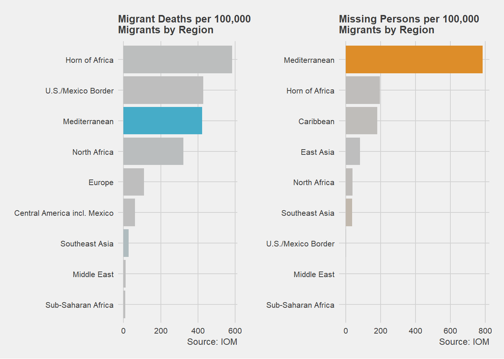

```r
library(ggplot2)
library(gridExtra)

newsub <- regions[regions$dead >= 115,]

# Look at the distribution of deaths by region
p <- ggplot(newsub, aes(x=reorder(incident_location, death_100k), y=death_100k)) +
  geom_bar(aes(fill=missing),stat='identity') +
  coord_flip() + theme_fivethirtyeight(base_size = 10, base_family = "sans") +
  scale_fill_gradientn(name='',colors=colorRampPalette(c("gray","#46ACC8"))(10)) +
  theme(legend.position='none',plot.title = element_text(size =10)) +
  labs(caption = "Source: IOM") +
  ggtitle('Migrant Deaths per 100,000\nMigrants by Region')

# clean and plot missing persons by region
missing_sums <- subset(regions, missing >= 1)

missing_sums  <- arrange(missing_sums , missing)
missing_sums$incident_location <- factor(missing_sums$incident_location, levels = missing_sums$incident_location[order(missing_sums$missing)])

p1 <- missing_sums %>%
  ggplot(aes(x=reorder(incident_location,missing_100k),y=missing_100k)) +
  geom_bar(aes(fill=missing),stat='identity') +
  coord_flip() + theme_fivethirtyeight(base_size = 10, base_family = "sans") +
  scale_fill_gradientn(name='',colors=colorRampPalette(c("gray","#DD8D29"))(10)) +
  theme(legend.position='none',plot.title = element_text(size =10)) +
  labs(caption = "Source: IOM") +
  ggtitle('Missing Persons per 100,000\nMigrants by Region')


grid.arrange(p,p1,ncol=2)
```

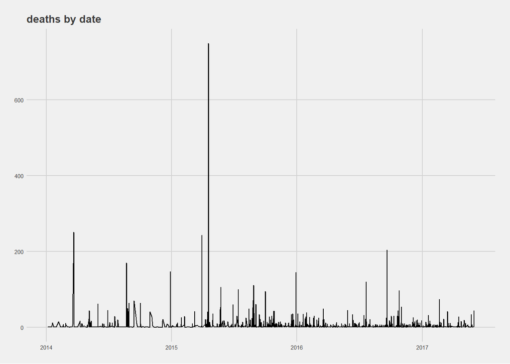

```r
# plot missing persons and deaths over time

#deaths by date
p4 <- ggplot(missing, aes(x=date, y=dead)) +
  geom_line() +
  theme_fivethirtyeight(base_size = 7, base_family = "sans") +
  ggtitle("deaths by date")
p4
```

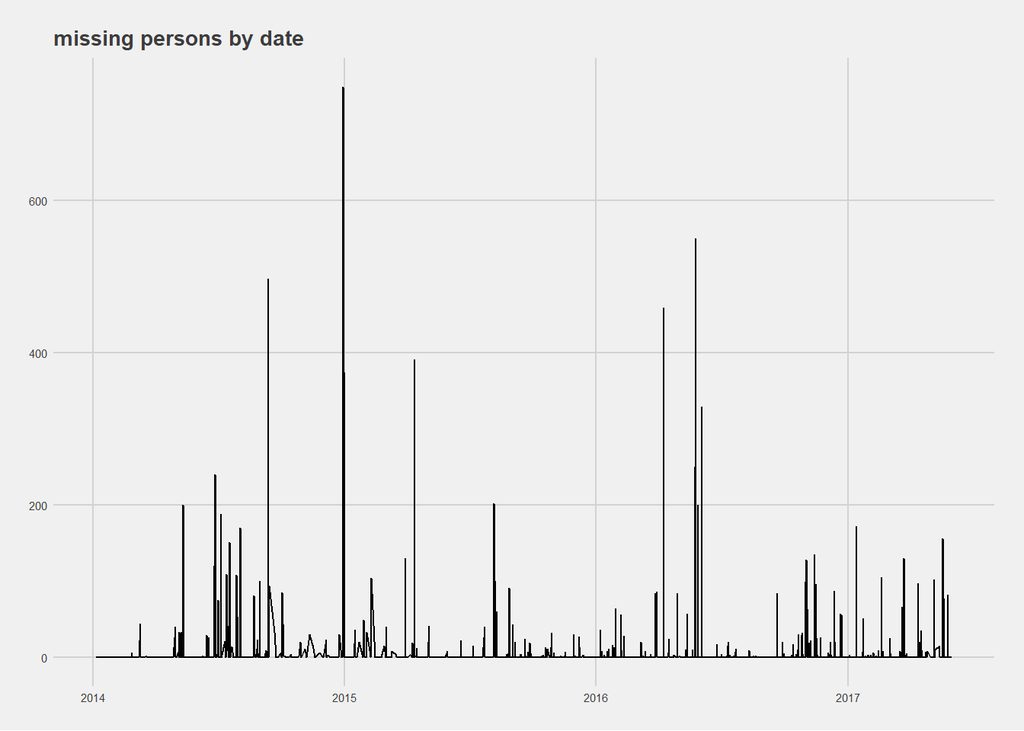

```r
# missing persons by date
p5 <- ggplot(missing, aes(x=date, y=missing)) +
  geom_line() +
  theme_fivethirtyeight(base_size = 7, base_family = "sans") +
  ggtitle("missing persons by date")
p5
```

The Nationality column is a pretty messy column. I’m liking the region of origin variable after exploring how Nationality is tracked in the data set.

We’ve got about 220 categories of nationalities. Some are duplicates like ‘Mexico’ and ‘Mexican’. Others have some ethnic suggestions to them such as ‘Myanmar’ and ‘Myanmar (Rohingya)’. Others vary like categories for Syria such as Syria’, ‘Syrian’ and ‘Syria Arab Republic’… even ‘African’ and ‘Sub-Saharan’…wondering how accurate these categories actually are…could a sub-saharan nationality been classified as ‘African’ when the data set was created? I’m even seeing some columns with multiple nationalities and ethnicities listed. Cleaning this up is going to take some time. There are also a lot of unknowns in this column - 1567 to be exact. Still hard to tell how much value can be derived from this column given how messy it is and the amount of unknowns.

```r
nations <- missing %>%
    group_by(nationality) %>%
    count()
nations <- as.data.frame(nations)
head(nations, 20)
```

|  | nationality | n |
| --- | --- | --- |
| 1 | 'African' | 2 |
| 2 | 'Mostly African' | 1 |
| 3 | 'Sub-Saharan African' | 2 |
| 4 | 1 Honduran, 3 Mexican | 1 |
| 5 | 1 Nigerian, others unknown. Survivors all from Sub-Saharan Africa | 1 |
| 6 | 1 Venezuelan, 1 unknown | 1 |
| 7 | 13 Cuba, 1 Dominican Republic, 1 Colombia | 1 |
| 8 | 15 dead from Palestine. Missing are from Palestine, Syria, and Egypt | 1 |
| 9 | 2 from Niger | 1 |
| 10 | 2 Senegal, 2 Guinea, 1 Ghana | 1 |

[output cut: 10 more lines]

## Data Carpentry on Cause of Death Column

Let’s focus on the tricky cause of death column. Here we see hundreds of causes of death. The cause of death column has 290 different categorical variables. There appear to be some variables that are the same with different spellings. Others appear to have a lot of detail, but this detail is going to be difficult for anyone to make sense of when looking for patterns in the data. It would be great if they used some type of standard classification method here to make sense of what’s going on. Going forward we’re going to need to clean this up, address the spelling issues, and collapse certain categories.

Before we get started I found this helpful resource from IOM. resource: https://missingmigrants.iom.int/sites/default/files/gmdac_data_briefing_series_issue4.pdf

On page 5 of their report, the missing migrants project seems to have collapsed or at least they are presenting the causes of death in a limited number of categories. This is a helpful start. When collapsing variable values we’ll try use this structure as a starting point and see how far we get.

Before we start cleaning let’s look at all the cause of death values.

```r
count <- missing %>%
    group_by(cause_death) %>%
    count()

count <- as.data.frame(count)
head(count, 20) # limit the print because there are too many
```

|  | cause_death | n |
| --- | --- | --- |
| 1 | AH1N1 influenza virus, while stuck at border | 1 |
| 2 | Asphyxiation | 5 |
| 3 | Asphyxiation (Silica sand inhalation) | 1 |
| 4 | Asphyxiation and crushing | 1 |
| 5 | Assaulted by smugglers | 1 |
| 6 | Attacked by hippopotamus | 2 |
| 7 | Beat-up and killed | 1 |
| 8 | Beat-up and thrown into river | 1 |
| 9 | Beaten to death on train | 1 |
| 10 | Beating/shot by traffickers | 2 |

[output cut: 10 more lines]

```r
# subset the dataframe to the following regions: Europe, Mediterranean, Middle East, North Africa
missing_med <- subset(missing, incident_location == "Europe" | incident_location == "Mediterranean" | incident_location == "Middle East" | incident_location =="North Africa")

#check the data set.  We're down to 1415 variables.
str(missing_med)
```

```
## Classes 'tbl_df', 'tbl' and 'data.frame':    1415 obs. of  12 variables:
##  $ id               : int  1 4 6 8 9 10 11 12 13 14 ...
##  $ cause_death      : chr  "Presumed drowning" "Presumed drowning" "Drowning" "Drowning" ...
##  $ origin           : chr  "Middle East" "Middle East" "MENA" "MENA" ...
##  $ nationality      : chr  "Iraq" "Unknown" "Unknown" "Unknown" ...
##  $ missing          : num  1 0 6 0 0 0 0 0 0 7 ...
##  $ dead             : num  1 1 4 11 1 1 3 1 1 3 ...
##  $ incident_location: chr  "Mediterranean" "Mediterranean" "Mediterranean" "Mediterranean" ...
##  $ date             : Date, format: "2015-11-05" "2015-11-03" ...
##  $ source           : chr  "IOM Greece" "Hellenic Coast Guard" "Reuters" "Hellenic Coast Guard" ...
##  $ reliability      : chr  "Verified" "Verified" "Partially Verified" "Verified" ...
##  $ lat              : num  36.9 36.5 37.3 37.8 38.4 ...
##  $ lon              : num  27.3 27.4 27.1 27 26.5 ...
```

```r
regions <- missing_med %>% group_by(incident_location) %>% summarise(sum(missing), sum(dead))
regions
```

| incident_location | sum(missing) | sum(dead) |
| --- | --- | --- |
| Europe | 0 | 230 |
| Mediterranean | 8989 | 4826 |
| Middle East | 11 | 190 |
| North Africa | 275 | 2257 |

Below are the new cause of death categories: These are pretty similar to what’s in the data set.

Drowning Medical Asphyxiation Vehicle Accident Train Accident Violence, Assault, Murder Exhaustion Starvation, Dehydration, Exposure Sexual Assault Accident Unknown

```r
# this was a bit tedious to reclassify these as appropriate.

cleanup <- function(df) {
    df <- gsub("Boat fire","Accident",df)
    df <- gsub("Asphyxiation and crushing", "Asphyxiation",df)
    df <- gsub("Beat-up and killed", "Violence, Assault, Murder",df)
    df <- gsub("Burned to death hiding in truck", "Vehicle Accident",df)
    df <- gsub("Burns and Suffocation", "Asphyxiation",df)
    df <- gsub("Burns from cooking gas explosion in connection house in Libya", "Accident",df)
    df <- gsub("Clubbed/beaten to death","Violence, Assault, Murder",df)
    df <- gsub("Crushed","Accident",df)
    df <- gsub("Crushed / drowning","Drowning",df)
        df <- gsub("Boat","Accident",df)
    df <- gsub("Accident / drowning","Accident",df)
    df <- gsub("Accident by bus on ferry","Accident",df)
    df <- gsub("Accident by pallets","Accident",df)
    df <- gsub("Accident to death","Accident",df)
    df <- gsub("Dehydration","Exhaustion, Starvation, Dehydration, Exposure",df)
    df <- gsub("Dehydration and exposure to the elements","Exhaustion, Starvation, Dehydration, Exposure",df)
    df <- gsub("Dehydration Harsh_weather_lack_of_adequate_shelter","Exhaustion, Starvation, Dehydration, Exposure",df)
    df <- gsub("Dehydration Harsh_weather_lack_of_adequate_shelter Suffocation Excessive_physical_abuse Sexual_abuse","Exhaustion, Starvation, Dehydration, Exposure",df)
    df <- gsub("Dehydration Suffocation Vehicle_Accident","Exhaustion, Starvation, Dehydration, Exposure",df)
    df <- gsub("Dehydration Vehicle_Accident Excessive_physical_abuse","Exhaustion, Starvation, Dehydration, Exposure",df)
    df <- gsub("Dehydration, Starvation","Exhaustion, Starvation, Dehydration, Exposure",df)
    df <- gsub("Died of unknown cause in hospital shortly after rescue","Unknown",df)
    df <- gsub("drowning","Drowning",df)
    df <- gsub("Drowning after being thrown overboard by other passengers","Drowning",df)
    df <- gsub("Drowning or suffocation in hull","Drowning",df)
    df <- gsub("Drowning, Asphyxiation","Drowning",df)
    df <- gsub("Drowning, Other","Drowning",df)
    df <- gsub("Drowning, Trampling","Drowning",df)
    df <- gsub("Drowning. Boat collided with ferry","Drowning",df)
    df <- gsub("Electrocuted on train","Train Accident",df)
    df <- gsub("Electrocution","Accident",df)
    df <- gsub("Electrocution on railway","Train Accident",df)
    df <- gsub("Excessive_physical_abuse","Violence, Assault, Murder",df)
    df <- gsub("Excessive_physical_abuse Sexual_abuse","Sexual Assault",df)
    df <- gsub("Excessive_physical_abuse Shot_or_Stabbed","Violence, Assault, Murder",df)
    df <- gsub("Exposure","Exhaustion, Starvation, Dehydration, Exposure",df)
    df <- gsub("Exposure, Hyperthermia","Exhaustion, Starvation, Dehydration, Exposure",df)
    df <- gsub("Exposure. Died upon entry to refugee camp.","Exhaustion, Starvation, Dehydration, Exposure",df)
    df <- gsub("Fell from boat","Accident",df)
    df <- gsub("Fell from train","Train Accident",df)
    df <- gsub("Fell from truck","Vehicle Accident",df)
    df <- gsub("Fuel burns","Accident",df)
    df <- gsub("Fuel Inhalation","Asphyxiation",df)
    df <- gsub("Gylcemic crisis (Diabetic, medicine thrown overboard)","Medical",df)
    df <- gsub("Harsh conditions","Exhaustion, Starvation, Dehydration, Exposure",df)
    df <- gsub("Harsh_weather_lack_of_adequate_shelter","Exhaustion, Starvation, Dehydration, Exposure",df)
    df <- gsub("Harsh_weather_lack_of_adequate_shelter Excessive_physical_abuse","Exhaustion, Starvation, Dehydration, Exposure",df)
    df <- gsub("Harsh_weather_lack_of_adequate_shelter Excessive_physical_abuse Sexual_abuse","Exhaustion, Starvation, Dehydration, Exposure",df)
    df <- gsub("Harsh_weather_lack_of_adequate_shelter Other","Exhaustion, Starvation, Dehydration, Exposure",df)
    df <- gsub("Harsh_weather_lack_of_adequate_shelter Suffocation Vehicle_Accident","Exhaustion, Starvation, Dehydration, Exposure",df)
    df <- gsub("Harsh_weather_lack_of_adequate_shelter Vehicle_Accident","Exhaustion, Starvation, Dehydration, Exposure",df)
    df <- gsub("Head injury","Accident",df)
    df <- gsub("Head injury from fall","Accident",df)
    df <- gsub("Head trauma (hit by boat propeller)","Accident",df)
    df <- gsub("Hi by truck","Vehicle Accident",df)
    df <- gsub("Hit by car","Vehicle Accident",df)
    df <- gsub("Hit by train","Train Accident",df)
    df <- gsub("Hit by truck","Vehicle Accident",df)
    df <- gsub("Hit by vehicle","Vehicle Accident",df)
    df <- gsub("Hit by Vehicle","Vehicle Accident",df)
    df <- gsub("Homicide, likely by asphyxiation","Violence, Assault, Murder",df)
    df <- gsub("Hunger, fatigue","Exhaustion, Starvation, Dehydration, Exposure",df)
    df <- gsub("Hyperthermia","Exhaustion, Starvation, Dehydration, Exposure",df)
    df <- gsub("Hyperthermia, Abandoned by smugglers in the desert","Exhaustion, Starvation, Dehydration, Exposure",df)
    df <- gsub("Hyperthermia, starvation","Exhaustion, Starvation, Dehydration, Exposure",df)
    df <- gsub("Hypothermia, Exhaustion","Exhaustion, Starvation, Dehydration, Exposure",df)
    df <- gsub("Hypothermia, Malnutrition","Accident",df)
    df <- gsub("Inhalation of toxic fumes from boat engine","Accident",df)
    df <- gsub("Injured from a fight","Violence, Assault, Murder",df)
    df <- gsub("Killed","Violence, Assault, Murder",df)
    df <- gsub("NA","Unknown",df)
    df <- gsub("Presumed Drowning","Drowning",df)
    df <- gsub("Hypothermia","Exhaustion, Starvation, Dehydration, Exposure",df)
    df <- gsub("Unknown (found on motorway)","Unknown",df)
    df <- gsub("Unspecified location between North Africa and Italy. Body brought to Calabria.","Unknown",df)
    df <- gsub("Starvation, Exhaustion, Starvation, Dehydration, Exhaustion, Starvation, Dehydration, Exposure, Exhaustion","Exhaustion, Starvation, Dehydration, Exposure",df)
    df <- gsub("Exhaustion, Starvation, Dehydration, Exposure, Abandoned by smugglers in the desert","Exhaustion, Starvation, Dehydration, Exposure",df)
    df <- gsub("Toxic fumes/asphyxiation","Asphyxiation",df)
    df <- gsub("Shot","Violence, Assault, Murder ",df)
    df <- gsub("Plane stowaway","Unknown",df)
    df <- gsub("Suffocation, Trampled","Asphyxiation",df)
    df <- gsub("Pulmonary edema","Medical",df)
    df <- gsub("Suffocation","Asphyxiation",df)
    df <- gsub("Unknown (body recovered from boat)","Unknown",df)
    df <- gsub("Unknown (found dead on top of train)","Unknown",df)
    df <- gsub("Unknown (body recovered from boat)","Unknown",df)
    df <- gsub("Presumed asphyxiation","Asphyxiation",df)
    df <- gsub("Vehicle accident","Vehicle Accident",df)
    df <- gsub("Gylcemic crisis (Diabetic, medicine thrown overboard)","Medical",df)
    df <- gsub("Unknown, plane stowaway","Unknown",df)
    df <- gsub("Violent robbery","Violence, Assault, Murder",df)
    df <- gsub("Meningitis","Medical",df)
    df <- gsub("Exhaustion, Starvation, Dehydration, Exposure, hypothermia","Exhaustion, Starvation, Dehydration, Exposure",df)
    df <- gsub("Accident from fall","Accident",df)
    df <- gsub("Accident on railway","Train Accident",df)
    df <- gsub("Asphyxiation Vehicle_Accident","Asphyxiation",df)
    df <- gsub("Asphyxiation, Other","Asphyxiation",df)
    df <- gsub("Drowning. Accident collided with ferry","Drowning",df)
    df <- gsub("Drowning. Accident collided with ferry","Unknown",df)
    df <- gsub("Exhaustion, Exhaustion, Starvation, Dehydration, Exposure, Exhaustion, Starvation, Dehydration, ","Exhaustion, Starvation, Dehydration, Exposure",df)
    df <- gsub("Likely Drowning ","Drowning",df)
    df <- gsub("Lung infection","Medical",df)

    return(df)
}

# this function helps, but there's still a lot of categories that need cleaning.
missing_med$cause_death <- cleanup(missing_med$cause_death)


# further cleaning up this column using using a more flexible technique.
missing_med$cause_death[startsWith(missing_med$cause_death, "Exhaustion")] <- "Exhaustion, Starvation, Dehydration, Exposure"
missing_med$cause_death[startsWith(missing_med$cause_death, "Starvation")] <- "Exhaustion, Starvation, Dehydration, Exposure"
missing_med$cause_death[startsWith(missing_med$cause_death, "Violence")] <- "Violence, Assault, Murder"
missing_med$cause_death[startsWith(missing_med$cause_death, "Sickness")] <- "Medical"
missing_med$cause_death[startsWith(missing_med$cause_death, "Gylcemic")] <- "Medical"
missing_med$cause_death[startsWith(missing_med$cause_death, "Head trauma")] <- "Medical"
missing_med$cause_death[startsWith(missing_med$cause_death, "Likely suffocation")] <- "Asphyxiation"
missing_med$cause_death[startsWith(missing_med$cause_death, "Murdered")] <- "Violence, Assault, Murder"
missing_med$cause_death[startsWith(missing_med$cause_death, "Likely Drowning")] <- "Drowning"
missing_med$cause_death[startsWith(missing_med$cause_death, "On board violence")] <- "Unknown"
missing_med$cause_death[startsWith(missing_med$cause_death, "Plane Stowaway")] <- "Unknown"
missing_med$cause_death[startsWith(missing_med$cause_death, "Presumed dehydration")] <- "Exhaustion, Starvation, Dehydration, Exposure"
missing_med$cause_death[startsWith(missing_med$cause_death, "Other")] <- "Unknown"
missing_med$cause_death[startsWith(missing_med$cause_death, "Presumed violence")] <- "Violence, Assault, Murder"
missing_med$cause_death[startsWith(missing_med$cause_death, "Probable Drowning")] <- "Drowning"
missing_med$cause_death[startsWith(missing_med$cause_death, "Respiratory problem")] <- "Medical"
missing_med$cause_death[startsWith(missing_med$cause_death, "Road accident")] <- "Vehicle Accident"
missing_med$cause_death[startsWith(missing_med$cause_death, "Sexual_abuse")] <- "Sexual Assault"
missing_med$cause_death[startsWith(missing_med$cause_death, "Tekeze River, near Himora, Ethiopia")] <- "Unknown"
missing_med$cause_death[startsWith(missing_med$cause_death, "Train accident")] <- "Sexual Assault"
missing_med$cause_death[startsWith(missing_med$cause_death, "Stabbed")] <- "Violence, Assault, Murder"
missing_med$cause_death[startsWith(missing_med$cause_death, "Truck crash")] <- "Vehicle Accident"
missing_med$cause_death[startsWith(missing_med$cause_death, "Unclear")] <- "Unknown"
missing_med$cause_death[startsWith(missing_med$cause_death, "Vehicle incident")] <- "Vehicle Accident"
missing_med$cause_death[startsWith(missing_med$cause_death, "Vehicle_Accident")] <- "Vehicle Accident"
missing_med$cause_death[startsWith(missing_med$cause_death, "Undernourished")] <- "Exhaustion, Starvation, Dehydration, Exposure"
missing_med$cause_death[startsWith(missing_med$cause_death, "Unknown")] <- "Unknown"
missing_med$cause_death[startsWith(missing_med$cause_death, "unknown")] <- "Unknown"

# We've got some leftover NAs encoded as <NA> in the data.  The normal na removal code isn't
# working so this bit tranforms things and changes these to unknown.
missing_med$cause_death[is.na(missing_med$cause_death)] <- 0
missing_med$cause_death <- gsub(0,"Unknown", missing_med$cause_death)


# View new cause of death categories and sum the missing persons and death counts
missing_med %>%
    group_by(cause_death) %>%
    summarise(sum(missing), sum(dead))
```

| cause_death | sum(missing) | sum(dead) |
| --- | --- | --- |
| Accident | 15 | 37 |
| Asphyxiation | 5 | 334 |
| Drowning | 8953 | 4157 |
| Exhaustion, Starvation, Dehydration, Exposure | 33 | 744 |
| Medical | 0 | 821 |
| Sexual Assault | 0 | 18 |
| Suicide | 0 | 1 |
| Train Accident | 0 | 18 |
| Unknown | 269 | 428 |
| Vehicle Accident | 0 | 489 |

[output cut: 1 more lines]